# Rare Pteridophytes are disproportionately frequent in the tropical forest of Xishuangbanna, Yunnan, China - ScienceDirect

[figure not shown]

[figure not shown]

## [Acta Oecologica](https://www.sciencedirect.com/science/journal/1146609X)

[Volume 110](https://www.sciencedirect.com/science/journal/1146609X/110/supp/C), May 2021, 103717

# Rare Pteridophytes are disproportionately frequent in the tropical forest of Xishuangbanna, Yunnan, China

[DanieleCicuzza<sup>a</sup><sup>b</sup>](https://www.sciencedirect.com/science/article/pii/S1146609X21000163#!)

https://doi.org/10.1016/j.actao.2021.103717[Get rights and content](https://s100.copyright.com/AppDispatchServlet?publisherName=ELS&contentID=S1146609X21000163&orderBeanReset=true)

## Highlights

**•**

130 pteridphytes assessed, with plot-based method, in tropical forest (China).

**•**

The 66% of the 99 terrestrial species were considered rare.

**•**

The 97% of the 31 epiphyte species were considered rare.

**•**

Rare epiphytic species, richness and cover, was higher at higher elevation.

**•**

Rare terrestrial species, richness and cover, was higher at lowland sites.

## Abstract

Both rare and common epiphytic species had higher richness and cover values at higher elevations. While common [epiphytes](https://www.sciencedirect.com/topics/agricultural-and-biological-sciences/epiphyte) had higher cover values at a high elevation in the northern aspect, the rare epiphyte species were richer at a higher elevation for both aspects. The richness and cover of the terrestrial species was negatively correlated with elevation and there was a significant interaction. Specifically, most of the rare and common terrestrial ferns were in the [lowland](https://www.sciencedirect.com/topics/agricultural-and-biological-sciences/lowlands) sites of Xishuangbanna (from 600 m a.s.l.) However, only 20 species out of the total 130 species contributed to a total cover above 50% with the other species having only a minor density. Our results emphasize the high number of rare species with a low occurrence and show there to be a conservation concern in the fragmented tropical landscape of southern Yunnan.

## Keywords

Pteridophytes

Rarity

Plant ecology

Tropical East Asia

Conservation

China

## 1. Introduction

In tropical landscapes, plant species composition indicates a high disparity between common and rare species (Leita et al., 2016; Zizka et al., 2018). The proportion between common and rare species is related to their evolutionary history and environmental factors (Linder, 2019). This is particularly high and relevant in tropical habitats (Backes et al., 2019). At the geographical distribution level, species are generally considered to be rare in relation to the three characteristics of their geographic range, habitat specificity and local population size (Rabinowitz, 1981; Gaston, 1994; Gaston and Fuller, 2009). The definition of rare species includes those with small localized populations and individuals that occur at extremely low frequencies. In the tropical and subtropical habitats subset of widespread trees (Williams et al., 2017) and herbaceous species (Liu et al., 2017), they dominate over rare species which occurs with lower frequency and in a smaller distribution area.

An excellent system in which to explore the ratio between rare and common taxa and their distribution is the [fern and fern allies](https://www.sciencedirect.com/topics/agricultural-and-biological-sciences/fern-ally) species (hereafter called only “ferns” for simplicity). Ferns are a common taxonomic group with their peak of diversity in the tropics for both terrestrial and epiphytic life forms (Atkinson et al., 2000; Kreft and Jetz, 2007). Species diversity increases from the lowlands up towards the mountain sites with greater epiphytic species richness at higher elevations. At the continental scale, fern species distribution is primarily explained by climatic factors such as temperature and cloud cover (Khine et al., 2019) whereas at the more local scale, the fern community composition is strongly related to topography, slope and its proximity to river or humid sites (Jones et al., 2016) with the presence of given families and genera richness in species composition and cover values. Ferns are able to colonize a wide range of niches and have the ability to cope with drought due their improved hydraulic transport which avoids [cavitation](https://www.sciencedirect.com/topics/earth-and-planetary-sciences/cavitation-flow) (Pittermann et al., 2011). Their vein and stomatal density allows for better water use efficiency (Murphy et al., 2017).

Elevation and aspect are the two environmental factors that have a great influence on the ferns and other herbaceous terrestrial and epiphytic species (Moeslund et al., 2013; Tremblay and Castro, 2009). Elevation is often correlated with an increase in air humidity which is more suitable for fern species (Karger et al., 2012). Rare species tend to increase their species richness along the elevational gradient (Bhattarai et al., 2004; Merckx et al., 2015). This is due to the increase of more suitable niches such as emerging rocks or humid habitats (Kluge and Kessler, 2011b). The northern and southern aspects, with their different microclimatic conditions, play a crucial role in fern species distribution. Ferns indicate a clear demarcation of the microclimatic partition between the drier southern aspect sites with lower richness and the contrasting humid northern aspect sites (Jones et al., 2011). Moreover, if epiphytic fern assemblages have their pick at mid-elevation, the climate acts as a filter in favor of the species that have distinct morphological traits and can cope with the local microclimatic condition (Kluge and Kessler, 2011a). Common species are often more generalist whereas rare species tend to be more specialized in their ecology and habitats (Guo et al., 2013). In some cases, they are primarily found in understory habitats (Davidar et al., 2018).

In the South-west of China, Xishuangbanna prefecture, biodiversity studies have reported that the northern aspect hills are statistically important when explaining tree richness (Liu and Slik, 2014). However, tree data poorly predicts diversity and the abundance of fern species (Pasion et al., 2018). Fern diversity in this area is different between the tropical forests with acidic soil and those with a limestone substrate with a complete turn-over of species (Phoutthavong et al., 2019). However, our understanding of the different patterns between common and rare fern species remains limited.

Understanding how the extraordinary diversity of rare species can be maintained at the local level and over a fragmented tropical forest landscape is crucial in ecological studies as well as for conservation actions. The present study is part of a larger research project that aims to document the richness of ferns and their conservation status in the tropical, human fragmented landscape of Xishuangbanna, southern Yunnan, China. The study evaluates both common and rare fern species and their life forms in relation to [abiotic factors](https://www.sciencedirect.com/topics/earth-and-planetary-sciences/abiotic-factor). More specifically, I asked the following questions: 1) How many rare and common ferns species occur in the Xishuangbanna prefecture? 2) Is the richness of the common and rare species different between the drier and humid sites? and 3) Is elevation and the local aspects a major player for the cover values of rare and common fern species?

## 2. Methods

### 2.1. Study area

The autonomous prefecture of Xishuangbanna is located south of Yunnan between 21° 09′N and 22° 36′N and between 99° 58′E and 101° 50′E (Fig. 1). Xishuangbanna occupies an area of 19,690 km<sup>2</sup> comprised of mountainous and hilly terrain with the highest peak at 2429 m asl and the lowest point at 480 m asl. The seasonality was strong with a dry season from November to May and a wet season from May to October. The prefecture is crossed by the Mekong River, located in its center and running approximately from north to south. The forest vegetation was classified into four forms: tropical rain forest, tropical mountain rain forest, tropical seasonal mountain forest and tropical mountain evergreen broad-leaved forest (Hua, 2006). The southern part of the prefecture (Mengla county) has a tropical rain forest with a unique [dipterocarp](https://www.sciencedirect.com/topics/agricultural-and-biological-sciences/dipterocarpaceae) species, Parashorea chinensis (Dipterocarpaceae). The forests with *P.* chinensis are richer in species and similar to tropical SE Asian forests. In contrast, the north and north-west of the prefecture, due to an average higher elevation, has tropical mountain forests with more deciduous tree species (Hua, 2006).

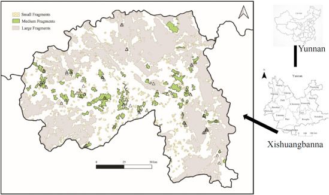

Fig. 1. Forest landscape map of Xishuangbanna prefecture. The fragments were classified into small (0.4-1 Km<sup>2</sup>), medium (1-10 Km<sup>2</sup>) and large (>10 Km<sup>2</sup>). The triangles represent the location where the transects were performed.

### 2.3. Data analyses

Fern species richness and cover were the two dependent variables considered in this study. Species richness consisted of the total number of species assessed in each transect and species cover was calculated using the mean of the cover value species per transect. The contributions of common and rare species to the total species richness were determined by correlating the overall richness to the richness in the subsets of species (Lennon et al., 2004). A species could be classified as rare if its distribution fit one of the three criteria: a narrow geographic range, a high habitat specificity/low occurrence or a consistently small population size (Song et al., 2015). I used only the data assessed according to the 75 transects of this study to assign rarity classes to the fern species, hereafter referred to as 'local rarity'. The species were ranked in order of increasing number. The species with only one record of their presence throughout all of the transects were considered to have a narrow distribution while those with more than one record had a wide distribution. For each distribution category, a second ranking was performed for species cover. Species with a cover index of less than 10% were considered to have low cover and species with a cover index greater than 10% were defined as having high cover (Vanderpoorten and Engels, 2003). This classification resulted in four different categories for the species’ geographic range: a wide range of distribution with high or low cover and a narrow range of distribution with high or low cover. Species were considered to be locally rare when they had a wide distribution with a low cover value and when they had a narrow distribution with low or high cover. This last category is justified because in our study area, narrow distribution with a high cover implied species that the recorded in a single site with a cover value above 10% were locally abundant but still poorly represented in the large Xishuangbanna landscape. For most of the common families and species, relative occurrence (Ro) and relative cover value (Rc) were calculated using the Ro = occurrence of the given species, specifically the total occurrence of the total species. The same method was used for the relative cover values with cover value as the units.

Furthermore, to test whether the richness of rare species per transect was correlated with the total number of species per transect, a Pearson correlation test was performed. A generalized linear model (GLM) was also performed to examine the effects of the environmental variables on the rare and common fern species richness and cover at the landscape level. For the GLM, a Poisson error distribution was used. The independent variables included in the model were elevation and aspect. Before inclusion in the model, the aspect, a circular variable expressed in degrees, was transformed with trigonometric sin (aspect) and cos (aspect) formula representing the respective northness and eastness aspects. All analyses were conducted using the R statistical software 3.5.1 with the R packages Vegan and Visreg (Oksanen, 2013).

## 3. Results

### 3.1. Taxonomic richness and composition

The total richness of the fern species in Xishuangbanna's forested landscape was of 130 species in 75 transects. Of these 130 species, 99 (76% of all species) had a terrestrial life form and the remaining 31 species (24%) had an epiphytic life form (Table 1 Add. Mat). The fern cover index, estimated per transect, varied between 1 and 100% with an average cover of 21%. The number of species per transect ranged from 1 to 14 for all [ferns](https://www.sciencedirect.com/topics/agricultural-and-biological-sciences/fern-ally) (Mean = 6.8 ± 2.7), from 0 to 12 for terrestrial ferns (Mean = 4.8 ± 2.0) and 0 to 6 for epiphytic species (Mean = 2.0 ± 1.2). The 130 species belonged to 46 genera and 18 families (Table 1 Add. Mat). The three richest families were [Polypodiaceae](https://www.sciencedirect.com/topics/agricultural-and-biological-sciences/polypodiaceae), Pteridaceae and Thelypteridaceae with 20 (15%), 18 (14%) and 14 (11%) species respectively (with the total percentage in parentheses). The three most frequent species recorded were *Woodwardia japonica* (L. f.) Sm. (relative occurrence Ro = 7.9%, relative cover value Rc = 19.9%), *Athyrium dissitifolium* (Baker) C. Christensen (Ro = 6.5%, Rc = 3.6%) and *Lygodium japonicum* (Thunberg) Swartz (Ro = 6.3%, Rc = 2.0%), whereas the three species with the highest cover values were *Woodwardia japonica* (L. f.) Sm., *Cibotium barometz* (L.) J. Sm. (Ro = 4.0%, Rc = 16.0%) and *Arachniodes cavaleriei* (Christ) Ohwi (Ro = 1.7%, Rc = 5.3%). The three most frequent epiphytic species were *Davallia solida* (G. Foster) Swartz (Ro = 11.2%, Rc = 10.8%), *Pyrrosia lanceolata* (L) Farwell (Ro = 9.2%, Rc = 8.8%) and *Lepisorus annamensis* (C. Christensen) Li Wang (Ro = 3.1%, Rc = 6.7%).

Table 1. Local rarity analysis for terrestrial and epiphytic fern species in Xishuangbanna, Yunnan. The values represent the number of species for each category and the corresponding percentage in parentheses.

|  | Geographic Range Wide | Geographic Range Wide | Geographic Range Narrow | Geographic Range Narrow |
| --- | --- | --- | --- | --- |
| Number of species | High cover (Common) | Low cover (Rare) | High cover (Rare) | Low cover (Rare) |
| Total | 35 (27%) | 51 (40%) | 1 (1%) | 43 (33%) |
| Terrestrial | 34 (34%) | 29 (30%) | 1 (1%) | 35 (35%) |
| Epiphytic | 1 (3%) | 22 (71%) | 0 (0%) | 8 (26%) |

### 3.2. Species rarity

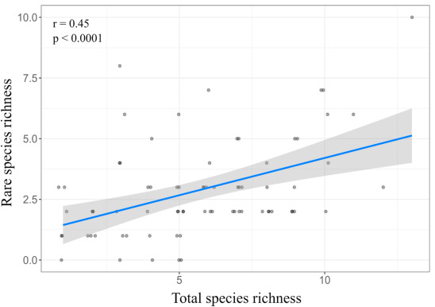

Fig. 2. Pearson correlation between the total species richness and rare species richness per transect from the 75 transects in Xishuangbanna (r = 0.448, p < 0.001).

### 3.3. Effects of elevation and aspect on species richness and cover

The epiphytic fern richness of common species showed a positive increase with elevation, whereas the model showed that the number of rare epiphytic species increased with elevation and in the dry and humid aspects. Terrestrial rare and common species had a negative trend with elevation. The total richness showed an interaction between elevation and the other aspects with a positive trend whereas the total richness of the common species had a negative trend with elevation (Table 2, Fig. 3). Moving to the cover values of the fern species, we observed that common and rare [epiphytes](https://www.sciencedirect.com/topics/agricultural-and-biological-sciences/epiphyte) have a positive trend with elevation, increasing their cover values in both dry and humid sites. The cover of rare terrestrial species has a negative pattern with elevation whereas for the common terrestrial species, the cover values decreased along the elevation as well for the drier and humid sites. To conclude, the cover value of all rare species increased with elevation whereas the total cover of common species decreased along the elevation, as observed in dry and humid sites (Table 2).

Table 2. The best model results (GLM) on the effect of the richness and cover values of both rare and common [ferns](https://www.sciencedirect.com/topics/agricultural-and-biological-sciences/fern-ally) species, separated according to terrestrial, epiphytic and total diversity, between the two explanatory variables considered, namely the elevation and topographic aspects and their interaction.

|  | Rare species Df | Rare species Deviance | Rare species AIC | Common species Df | Common species Deviance | Common species AIC |
| --- | --- | --- | --- | --- | --- | --- |
| **Epiphytic richness** |  |  |  |  |  |  |
| Elevation | -- | -- | -- | 1 | 42.231 | 66.231 |
| Elevation: Aspect | 1 | 91.115 | 199.56 | -- | -- | -- |
| **Terrestrial Richness** |  |  |  |  |  |  |
| Elevation | 1 | 95.456 | 250.24 | 1 | 120.02 | 339.89 |
| **Total Richness** |  |  |  |  |  |  |
| Elevation | -- | -- | -- | 1 | 119.92 | 342.94 |
| Elevation: Aspect | 1 | 91.743 | 298.83 | -- | -- | -- |
| **Epiphytic-Abundance** |  |  |  |  |  |  |
| Elevation: Aspect | 1 | 100.939 | 210.20 | 1 | 526.15 | 581.94 |
| **Terrestrial-Abundance** |  |  |  |  |  |  |
| Elevation | 1 | 244.15 | 415.40 |  |  |  |
| Elevation: Aspect | -- | -- | -- | 1 | 1352.5 | 1609.8 |
| **Total-Abundance** |  |  |  |  |  |  |
| Elevation | 1 | 211.57 | 429.35 | -- | -- | -- |
| Elevation: Aspect | -- | -- | -- | 1 | 1300.4 | 1607.1 |

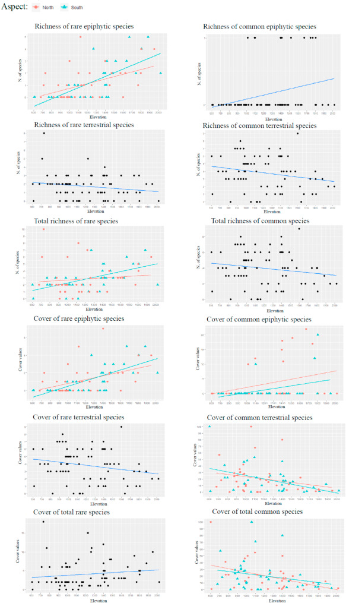

Fig. 3. Relationship between richness and cover with the variables of elevation, the topographic aspect and their interaction according to the results in Table 2.

## 4. Discussion

### 4.1. Fern species and rarity

The study reports that the majority of [ferns](https://www.sciencedirect.com/topics/agricultural-and-biological-sciences/fern-ally) species in the [forest habitat](https://www.sciencedirect.com/topics/agricultural-and-biological-sciences/forest-habitats) of Xishuangbanna Prefecture are locally rare. Two-thirds of terrestrial species are rare whereas nearly all [epiphytes](https://www.sciencedirect.com/topics/agricultural-and-biological-sciences/epiphyte) are rare. Spatially, the rare species are more frequent at higher elevations with the driest sites being slightly richer in terms of the epiphytes and the total number of species. Furthermore, the species cover shows that for terrestrial species, there is a decrease along the elevation with higher values at the [lowland](https://www.sciencedirect.com/topics/agricultural-and-biological-sciences/lowlands) sites. Common epiphytes increase along the elevation occurring at the north and south sites (Table 2). Overall, most of the species (73%) have a narrow or wide distribution but low cover values, showing that the fern species in Xishuangbanna Prefecture tend to have a population size characterized by low cover and few individuals. The epiphytic life forms that were considered locally rare reached 97%. Two-thirds of these species have a wide distribution (collected in more than one transect) with low abundance.

### 4.2. Fern species’ elevation and topographic aspects

It is important to note that in tropical [plant ecology](https://www.sciencedirect.com/topics/agricultural-and-biological-sciences/plant-ecology), a high number of species are recorded once in the plot or transect-based method. For example, in the Amazonian basin, 23% of terrestrial ferns species have been recorded once (Tuomisto, Hanna, Ruokolainen, 1993). For trees species in Borneo, out of over 230 species, 27 were recorded once, 43 twice and 23 and 16 three and four times respectively (Sheil et al., 2010). Beside *Parashorea chinensis*, other species have the southern part of Yunnan as their northern area of distribution as they are mainly centered in South East Asia (Hua, 2006). However, the species at this latitude tend to decrease their density and become rare (Cai et al., 2019; Liu et al., 2019). Therefore, it can be concluded that the high level of rarity among the ferns species is the combination of the ecological aspects as well as the northern limit distribution of many species recorded in this study.

## 5. Conclusion

Moreover, the expansion of rubber plantations in Xishuangbanna has evolved from the lowlands to a higher elevation (Kou et al., 2018), even inside protected areas (Jin and Fan, 2018) with forests set aside in the northern aspect sites that harbour high tree species diversity and high fern species abundance (Liu and Slik, 2014). However, rare epiphytic species occur also in the southern mountain sites with high richness and a low level of occurrence. Unfortunately, these sites have already been affected by the rubber expansion. In conclusion, an ecological study is important not only to consider the major woody plant community but also to include the neglected groups with low occurrence that considerably contribute to plant richness.

## Funding sources

This project was funded by the Chinese Academy of Science (CAS) within the 1-3-5 initiative of Xishuangbanna Tropical [Botanical Garden](https://www.sciencedirect.com/topics/earth-and-planetary-sciences/botanical-garden).

## Author contribution

DC conducted the research, compiled, and analyzed the data, designed the study and wrote the paper via multiple rounds of revision.

## Declaration of competing interest

The authors declare that they have no known competing financial interests or personal relationships that could have appeared to influence the work reported in this paper.

## Acknowledgements

I want to thank Professor Richard Corlett for his continuous support and contributions to this project. I would also like to thank Dr Christos Mammides for his help in the statistical analysis. I also want to thank the XTBG staff for their help during the field work and laboratory activity. An extra acknowledgment goes to the Nature Reserve Bureau of Xishuangbanna Dai Autonomous Prefecture for the sampling permits. This work was funded by the CAS 1-3-5 initiative of Xishuangbanna Tropical [Botanical Garden](https://www.sciencedirect.com/topics/earth-and-planetary-sciences/botanical-garden).

## References

**Atkinson et al., 2000**

C.J. Atkinson, M. Policarpo, A.D. Webster, G. Kingswell

**Drought tolerance of clonal Malus determined from measurements of stomatal conductance and leaf water potential**

Tree Physiol., 20 (2000), pp. 557-563, 10.1093/treephys/20.8.557

[CrossRef](https://doi.org/10.1093/treephys/20.8.557)[View Record in Scopus](https://www.scopus.com/inward/record.url?eid=2-s2.0-0034177088&partnerID=10&rel=R3.0.0)Google Scholar

**Axmanová et al., 2012**

I. Axmanová, L. Tichý, Z. Fajmonová, P. Hájková, E. Hettenbergerová, C.F. Li, K. Merunková, M. Nejezchlebová, Z. Otýpková, M. Vymazalová, D. Zelený

**Estimation of herbaceous biomass from species composition and cover**

Appl. Veg. Sci., 15 (2012), pp. 580-589, 10.1111/j.1654-109X.2012.01191.x

[View Record in Scopus](https://www.scopus.com/inward/record.url?eid=2-s2.0-84865970010&partnerID=10&rel=R3.0.0)Google Scholar

**Backes et al., 2019**

A. Backes, G. Mäder, C. Turchetto, A.L. Segatto, J.N. Fregonezi, S.L. Bonatto, L.B. Freitas

**How diverse can rare species be on the margins of genera distribution?**

AoB PLANTS, 11 (2019), pp. 1-12, 10.1093/aobpla/plz037

[CrossRef](https://doi.org/10.5771/9783748904991-1)[Google Scholar](https://scholar.google.com/scholar?q=How%20diverse%20can%20rare%20species%20be%20on%20the%20margins%20of%20genera%20distribution)

**Bhattarai et al., 2004**

K.R. Bhattarai, O.R. Vetaas, J.a. Grytnes

**Fern species richness along a central Himalayan elevational gradient, Nepal**

J. Biogeogr., 31 (2004), pp. 389-400, 10.1046/j.0305-0270.2003.01013.x

[CrossRef](https://doi.org/10.1046/j.0305-0270.2003.01013.x)[View Record in Scopus](https://www.scopus.com/inward/record.url?eid=2-s2.0-1542319942&partnerID=10&rel=R3.0.0)Google Scholar

**Cai et al., 2019**

L. Cai, G. Zhang, J. Xiang, Z. Dao, W. Sun

**Rescuing Christensenia aesculifolia (Marattiaceae), a plant species with an extremely small population in China**

Oryx, 53 (2019), pp. 436-438, 10.1017/S003060531800039X

[CrossRef](https://doi.org/10.1017/s003060531800039x)[View Record in Scopus](https://www.scopus.com/inward/record.url?eid=2-s2.0-85052708774&partnerID=10&rel=R3.0.0)[Google Scholar](https://scholar.google.com/scholar?q=Rescuing%20Christensenia%20aesculifolia%20,%20a%20plant%20species%20with%20an%20extremely%20small%20population%20in%20China)

**Cardelus et al., 2006**

C.L. Cardelus, R.K. Colwell, J.E. Watkins

**Vascular epiphyte distribution patterns: explaining the mid-elevation richness peak**

J. Ecol., 94 (2006), pp. 144-156, 10.1111/j.1365-2745.2005.01052.x

[CrossRef](https://doi.org/10.1111/j.1365-2745.2005.01052.x)[View Record in Scopus](https://www.scopus.com/inward/record.url?eid=2-s2.0-31944447136&partnerID=10&rel=R3.0.0)Google Scholar

**Davidar et al., 2018**

P. Davidar, F. Munoz, J.P. Puyravaud, D. Mohandass, V.S. Ramachandran

**Multiple facets of rarity among rain forest trees in the Western Ghats of India**

Biol. Conserv., 228 (2018), pp. 110-119, 10.1016/j.biocon.2018.10.014

[Article](https://www.sciencedirect.com/science/article/pii/S0006320717314702)[Download PDF](https://www.sciencedirect.com/science/article/pii/S0006320717314702/pdfft?md5=7f3a0d30b5553d2b3c9df33a10694b6f&pid=1-s2.0-S0006320717314702-main.pdf)[View Record in Scopus](https://www.scopus.com/inward/record.url?eid=2-s2.0-85055191822&partnerID=10&rel=R3.0.0)Google Scholar

**Dong et al., 2017**

S. Dong, Z. Zuo, Y. Yan, J. Xiang

**Red list assessment of lycophytes and ferns in China**

Biodivers. Sci., 25 (2017), pp. 765-773, 10.17520/biods.2016204

[CrossRef](https://doi.org/10.17520/biods.2016204)[View Record in Scopus](https://www.scopus.com/inward/record.url?eid=2-s2.0-85029445035&partnerID=10&rel=R3.0.0)[Google Scholar](https://scholar.google.com/scholar_lookup?title=Red%20list%20assessment%20of%20lycophytes%20and%20ferns%20in%20China&publication_year=2017&author=S.%20Dong&author=Z.%20Zuo&author=Y.%20Yan&author=J.%20Xiang)

**Fu et al., 2016**

P.L. Fu, W.J. Liu, Z.X. Fan, K.F. Cao

**Is fog an important water source for woody plants in an Asian tropical karst forest during the dry season?**

Ecohydrology, 9 (2016), pp. 964-972, 10.1002/eco.1694

[CrossRef](https://doi.org/10.1002/eco.1694)[View Record in Scopus](https://www.scopus.com/inward/record.url?eid=2-s2.0-84953410734&partnerID=10&rel=R3.0.0)[Google Scholar](https://scholar.google.com/scholar?q=Is%20fog%20an%20important%20water%20source%20for%20woody%20plants%20in%20an%20Asian%20tropical%20karst%20forest%20during%20the%20dry%20season)

**Gaston, 1994**

K.J. Gaston

**Measuring range sizes geographic**

Oikos, 17 (1994), pp. 198-205

[CrossRef](https://doi.org/10.1111/j.1600-0587.1994.tb00094.x)[View Record in Scopus](https://www.scopus.com/inward/record.url?eid=2-s2.0-0028120555&partnerID=10&rel=R3.0.0)[Google Scholar](https://scholar.google.com/scholar_lookup?title=Measuring%20range%20sizes%20geographic&publication_year=1994&author=K.J.%20Gaston)

**Gaston, 2012**

K.J.K. Gaston

**The importance of being rare**

Nature, 487 (2012), pp. 46-47

https://www.nature.com/articles/487046a.pdf?origin=ppub

[CrossRef](https://doi.org/10.1038/487046a)[View Record in Scopus](https://www.scopus.com/inward/record.url?eid=2-s2.0-84863489062&partnerID=10&rel=R3.0.0)[Google Scholar](https://scholar.google.com/scholar_lookup?title=The%20importance%20of%20being%20rare&publication_year=2012&author=K.J.K.%20Gaston)

**Gaston and Fuller, 2009**

K.J. Gaston, R.A. Fuller

**The sizes of species' geographic ranges**

J. Appl. Ecol., 46 (2009), pp. 1-9, 10.1111/j.1365-2664.2008.01596.x

[CrossRef](https://doi.org/10.1111/j.1365-2664.2008.01596.x)[View Record in Scopus](https://www.scopus.com/inward/record.url?eid=2-s2.0-58249107946&partnerID=10&rel=R3.0.0)[Google Scholar](https://scholar.google.com/scholar?q=The%20sizes%20of%20species%20geographic%20ranges)

**Guo et al., 2013**

Y. Guo, J. Lu, S.B. Franklin, Q. Wang, Y. Xu, K. Zhang, D. Bao, X. Qiao, H. Huang, Z. Lu, M. Jiang

**Spatial distribution of tree species in a species-rich subtropical mountain forest in central China**

Can. J. For. Res., 43 (2013), pp. 826-835, 10.1139/cjfr-2013-0084

[CrossRef](https://doi.org/10.1139/cjfr-2013-0084)[View Record in Scopus](https://www.scopus.com/inward/record.url?eid=2-s2.0-84883532015&partnerID=10&rel=R3.0.0)Google Scholar

**Hua, 2006**

Z. Hua

**Forest vegetation of Xishuangbanna , south China**

Forestry Studies in China, vol. 8 (2006), 10.1007/s11632-006-0014-7

[Google Scholar](https://scholar.google.com/scholar_lookup?title=Forest%20vegetation%20of%20Xishuangbanna%20%2C%20south%20China&publication_year=2006&author=Z.%20Hua)

**Jin and Fan, 2018**

Y. Jin, H. Fan

**Land use/land cover change and its impacts on protected areas in Mengla County, Xishuangbanna, Southwest China**

Environ. Monit. Assess., 190 (2018), p. 509, 10.1007/s10661-018-6891-0

[View Record in Scopus](https://www.scopus.com/inward/record.url?eid=2-s2.0-85051512589&partnerID=10&rel=R3.0.0)[Google Scholar](https://scholar.google.com/scholar?q=Land%20useland%20cover%20change%20and%20its%20impacts%20on%20protected%20areas%20in%20Mengla%20County,%20Xishuangbanna,%20Southwest%20China)

**Jones et al., 2011**

M.M. Jones, B. Szyska, M. Kessler

**Microhabitat partitioning promotes plant diversity in a tropical montane forest**

Global Ecol. Biogeogr., 20 (2011), pp. 558-569, 10.1111/j.1466-8238.2010.00627.x

[CrossRef](https://doi.org/10.1111/j.1466-8238.2010.00627.x)[View Record in Scopus](https://www.scopus.com/inward/record.url?eid=2-s2.0-79958168429&partnerID=10&rel=R3.0.0)Google Scholar

**Jones et al., 2016**

M.M. Jones, K. Ruokolainen, N.C.L. Martinez, H. Tuomisto

**Differences in topographic and soil habitat specialization between trees and two understorey plant groups in a Costa Rican lowland rain forest**

J. Trop. Ecol., 32 (2016), pp. 482-497, 10.1017/S0266467416000419

[View Record in Scopus](https://www.scopus.com/inward/record.url?eid=2-s2.0-84983086541&partnerID=10&rel=R3.0.0)Google Scholar

**Karger et al., 2012**

D.N. Karger, J. Kluge, S. Abrahamczyk, L. Salazar, J. Homeier, M. Lehnert, V.B. Amoroso, M. Kessler

**Bryophyte cover on trees as proxy for air humidity in the tropics**

Ecol. Indicat., 20 (2012), pp. 277-281, 10.1016/j.ecolind.2012.02.026

[Article](https://www.sciencedirect.com/science/article/pii/S1470160X12000726)[Download PDF](https://www.sciencedirect.com/science/article/pii/S1470160X12000726/pdfft?md5=4762a9c97406e797827ab1a6c42c531f&pid=1-s2.0-S1470160X12000726-main.pdf)[View Record in Scopus](https://www.scopus.com/inward/record.url?eid=2-s2.0-84858414639&partnerID=10&rel=R3.0.0)Google Scholar

**Kessler et al., 2010**

M. Kessler, B.S. Parris, K. Elke

**A comparison of the tropical montane pteridophyte floras of mount Kinabalu , Borneo , and Parque Nacional Carrasco , Bolivia**

J. Biogeogr., 28 (2010), pp. 611-622

Google Scholar

**Khine et al., 2019**

P.K. Khine, J. Kluge, M. Kessler, G. Miehe, D.N. Karger

**Latitude-independent, continent-wide consistency in climate–richness relationships in Asian ferns and lycophytes**

J. Biogeogr., 46 (2019), pp. 981-991, 10.1111/jbi.13558

[CrossRef](https://doi.org/10.1111/jbi.13558)[View Record in Scopus](https://www.scopus.com/inward/record.url?eid=2-s2.0-85064483292&partnerID=10&rel=R3.0.0)[Google Scholar](https://scholar.google.com/scholar?q=Latitude-independent,%20continent-wide%20consistency%20in%20climaterichness%20relationships%20in%20Asian%20ferns%20and%20lycophytes)

**Kluge and Kessler, 2011a**

J. Kluge, M. Kessler

**Phylogenetic diversity, trait diversity and niches: species assembly of ferns along a tropical elevational gradient**

J. Biogeogr., 38 (2011), pp. 394-405, 10.1111/j.1365-2699.2010.02433.x

[CrossRef](https://doi.org/10.1111/j.1365-2699.2010.02433.x)[View Record in Scopus](https://www.scopus.com/inward/record.url?eid=2-s2.0-78751543424&partnerID=10&rel=R3.0.0)Google Scholar

**Kluge and Kessler, 2011b**

J. Kluge, M. Kessler

**Influence of niche characteristics and forest type on fern species richness, abundance and plant size along an elevational gradient in Costa Rica**

Plant Ecol., 212 (2011), pp. 1109-1121, 10.1007/s11258-010-9891-x

[CrossRef](https://doi.org/10.1007/s11258-010-9891-x)[View Record in Scopus](https://www.scopus.com/inward/record.url?eid=2-s2.0-79958044333&partnerID=10&rel=R3.0.0)Google Scholar

**Kou et al., 2018**

W. Kou, J. Dong, X. Xiao, A.J. Hernandez, Y. Qin, G. Zhang, B. Chen, N. Lu, R. Doughty

**Expansion dynamics of deciduous rubber plantations in Xishuangbanna, China during 2000–2010**

GIScience Remote Sens., 55 (2018), pp. 905-925, 10.1080/15481603.2018.1466441

[CrossRef](https://doi.org/10.1080/15481603.2018.1466441)[View Record in Scopus](https://www.scopus.com/inward/record.url?eid=2-s2.0-85046029679&partnerID=10&rel=R3.0.0)[Google Scholar](https://scholar.google.com/scholar?q=Expansion%20dynamics%20of%20deciduous%20rubber%20plantations%20in%20Xishuangbanna,%20China%20during%2020002010)

**Kreft and Jetz, 2007**

H. Kreft, W. Jetz

**Global patterns and determinants of vascular plant diversity**

Proc. Natl. Acad. Sci. U.S.A., 104 (2007), pp. 5925-5930, 10.1073/pnas.0608361104

[CrossRef](https://doi.org/10.1073/pnas.0608361104)[View Record in Scopus](https://www.scopus.com/inward/record.url?eid=2-s2.0-34347226358&partnerID=10&rel=R3.0.0)[Google Scholar](https://scholar.google.com/scholar_lookup?title=Global%20patterns%20and%20determinants%20of%20vascular%20plant%20diversity&publication_year=2007&author=H.%20Kreft&author=W.%20Jetz)

**Leita et al., 2016**

R.P. Leita, J. Zuanon, S. Villéger, S.E. Williams, C. Baraloto, C. Fortunel, F.P. Mendonc, D. Mouillot

**Rare species contribute disproportionately to the functional structure of species assemblages**

Proc. Biol. Sci. (2016), 10.1098/rspb.2016.0084

Google Scholar

**Lennon et al., 2004**

J.J. Lennon, P. Koleff, J.J.D. Greenwood, K.J. Gaston

**Contribution of rarity and commonness to patterns of species richness**

Ecol. Lett., 7 (2004), pp. 81-87, 10.1046/j.1461-0248.2004.00548.x

[View Record in Scopus](https://www.scopus.com/inward/record.url?eid=2-s2.0-1342269514&partnerID=10&rel=R3.0.0)Google Scholar

**Linder, 2019**

H.P. Linder

**Rare species, Restionaceae, and the Cape flora**

J. Biogeogr., 46 (2019), pp. 2637-2650, 10.1111/jbi.13709

[CrossRef](https://doi.org/10.1111/jbi.13709)[View Record in Scopus](https://www.scopus.com/inward/record.url?eid=2-s2.0-85073975551&partnerID=10&rel=R3.0.0)[Google Scholar](https://scholar.google.com/scholar_lookup?title=Rare%20species%2C%20Restionaceae%2C%20and%20the%20Cape%20flora&publication_year=2019&author=H.P.%20Linder)

**Liu and Slik, 2014**

J. Liu, J. Slik

**Forest fragment spatial distribution matters for tropical tree conservation**

Biol. Conserv., 171 (2014), pp. 99-106, 10.1016/j.biocon.2014.01.004

[Article](https://www.sciencedirect.com/science/article/pii/S0006320714000068)[Download PDF](https://www.sciencedirect.com/science/article/pii/S0006320714000068/pdfft?md5=a715d003841e16484549027022ec60c9&pid=1-s2.0-S0006320714000068-main.pdf)[View Record in Scopus](https://www.scopus.com/inward/record.url?eid=2-s2.0-84893447956&partnerID=10&rel=R3.0.0)[Google Scholar](https://scholar.google.com/scholar_lookup?title=Forest%20fragment%20spatial%20distribution%20matters%20for%20tropical%20tree%20conservation&publication_year=2014&author=J.%20Liu&author=J.%20Slik)

**Liu et al., 2017**

Y. Liu, Z. Shen, Q. Wang, X. Su, W. Zhang, N. Shrestha, X. Xu, Z. Wang

**Determinants of richness patterns differ between rare and common species: implications for Gesneriaceae conservation in China**

Divers. Distrib., 23 (2017), pp. 235-246, 10.1111/ddi.12523

[CrossRef](https://doi.org/10.1111/ddi.12523)[View Record in Scopus](https://www.scopus.com/inward/record.url?eid=2-s2.0-85008444971&partnerID=10&rel=R3.0.0)Google Scholar

**Liu et al., 2019**

H. Liu, H. Schneider, Y. Yu, T. Fuijwara, P.K. Khine

**Towards the conservation of the Mesozoic relict fern Christensenia: a fern species with extremely small populations in China**

J. Plant Res., 132 (2019), pp. 601-616, 10.1007/s10265-019-01131-9

[CrossRef](https://doi.org/10.1007/s10265-019-01131-9)[View Record in Scopus](https://www.scopus.com/inward/record.url?eid=2-s2.0-85071417182&partnerID=10&rel=R3.0.0)Google Scholar

**Merckx et al., 2015**

V.S.F.T. Merckx, K.P. Hendriks, K.K. Beentjes, C.B. Mennes, L.E. Becking, K.T.C.a. Peijnenburg, A. Afendy, N. Arumugam, H. de Boer, A. Biun, M.M. Buang, P.-P. Chen, A.Y.C. Chung, R. Dow, F.a. a. Feijen, H. Feijen, C.F. Soest, J. Geml, R. Geurts, B. Gravendeel, P. Hovenkamp, P. Imbun, I. Ipor, S.B. Janssens, M. Jocqué, H. Kappes, E. Khoo, P. Koomen, F. Lens, R.J. Majapun, L.N. Morgado, S. Neupane, N. Nieser, J.T. Pereira, H. Rahman, S. Sabran, A. Sawang, R.M. Schwallier, P.-S. Shim, H. Smit, N. Sol, M. Spait, M. Stech, F. Stokvis, J.B. Sugau, M. Suleiman, S. Sumail, D.C. Thomas, J. van Tol, F.Y.Y. Tuh, B.E. Yahya, J. Nais, R. Repin, M. Lakim, M. Schilthuizen

**Evolution of endemism on a young tropical mountain**

Nature (2015), 10.1038/nature14949

Google Scholar

**Moeslund et al., 2013**

J.E. Moeslund, L. Arge, P.K. Bøcher, T. Dalgaard, J.C. Svenning

**Topography as a driver of local terrestrial vascular plant diversity patterns**

Nord. J. Bot., 31 (2013), pp. 129-144, 10.1111/j.1756-1051.2013.00082.x

[CrossRef](https://doi.org/10.1111/j.1756-1051.2013.00082.x)[View Record in Scopus](https://www.scopus.com/inward/record.url?eid=2-s2.0-84877344411&partnerID=10&rel=R3.0.0)Google Scholar

**Murphy et al., 2017**

M.R.C. Murphy, G.J. Jordan, T.J. Brodribb

**Ferns are less dependent on passive dilution by cell expansion to coordinate leaf vein and stomatal spacing than angiosperms**

PloS One (2017), pp. 1-18, 10.1371/journal.pone.0185648

[View Record in Scopus](https://www.scopus.com/inward/record.url?eid=2-s2.0-85086923126&partnerID=10&rel=R3.0.0)Google Scholar

**Oksanen, 2013**

J. Oksanen

**Multivariate Analysis of Ecological Communities in R : Vegan Tutorial**

(2013)

[Google Scholar](https://scholar.google.com/scholar_lookup?title=Multivariate%20Analysis%20of%20Ecological%20Communities%20in%20R%C2%A0%3A%20Vegan%20Tutorial&publication_year=2013&author=J.%20Oksanen)

**Pasion et al., 2018**

B.O. Pasion, M. Roeder, J. Liu, M. Yasuda, R.T. Corlett, J.W.F. Slik, K.W. Tomlinson

**Trees represent community composition of other plant life-forms, but not their diversity, abundance or responses to fragmentation**

Sci. Rep., 8 (2018), pp. 2-14, 10.1038/s41598-018-29635-9

Google Scholar

**Phoutthavong et al., 2019**

K. Phoutthavong, A. Nakamura, X. Cheng, M. Cao

**Differences in pteridophyte diversity between limestone forests and non-limestone forests in the monsoonal tropics of southwestern China**

Plant Ecol., 220 (2019), pp. 917-934, 10.1007/s11258-019-00963-8

[CrossRef](https://doi.org/10.1007/s11258-019-00963-8)[View Record in Scopus](https://www.scopus.com/inward/record.url?eid=2-s2.0-85069960528&partnerID=10&rel=R3.0.0)Google Scholar

**Pittermann et al., 2011**

J. Pittermann, E. Limm, C. Rico, M.A. Christman

**Structure-function constraints of tracheid-based xylem: a comparison of conifers and ferns**

New Phytol., 192 (2011), pp. 449-461, 10.1111/j.1469-8137.2011.03817.x

[CrossRef](https://doi.org/10.1111/j.1469-8137.2011.03817.x)[View Record in Scopus](https://www.scopus.com/inward/record.url?eid=2-s2.0-80053231875&partnerID=10&rel=R3.0.0)Google Scholar

**Qin et al., 2017**

H. Qin, Y. Yang, S. Dong, Q. He, Y. Jia, L. Zhao, S. Yu, H. Liu, Bo Liu, Y. Yan, J. Xiang, N. Xia, H. Peng, Z. Li, Z. Zhang, X. He, L. Yin, Y. Lin, Quanru Liu, Y. Hou, Y. Liu, Qixin Liu, W. Cao, J. Li, S. Chan, Xiaohua Jin, T. Gao, W. Chen, H. Ma, Y. Geng, Xiaofeng Jin, C. Chang, H. Jiang, L. Cai, C. Zang, J. Wu, J. Ye, L. Yangjun, Bing Liu, Q. Lin, N. Xue

**Threatened species list of China's higher plants**

Biodivers. Sci., 25 (2017), pp. 696-744, 10.17520/biods.2017144

[CrossRef](https://doi.org/10.17520/biods.2017144)[View Record in Scopus](https://www.scopus.com/inward/record.url?eid=2-s2.0-85029447995&partnerID=10&rel=R3.0.0)[Google Scholar](https://scholar.google.com/scholar?q=Threatened%20species%20list%20of%20Chinas%20higher%20plants)

**Rabinowitz, 1981**

Rabinowitz D., 1981. Seven forms of rarity, in: Hugh Synge (Eds.), The biological aspects of rare plant conservation. John Wiley & Sons Ltd, pp: 205-217. https://www.esf.edu/efb/parry/Invert_Cons_14_Readings/Rabinowitz_1981.pdf.

Google Scholar

**Sheil et al., 2010**

D. Sheil, K. Kartawinata, I. Samsoedine, H. Priyadi, J.J. Afriastinid

**The lowland forest tree community in Malinau, Kalimantan (Indonesian Borneo): results from a one-hectare plot**

Plant Ecol. Divers., 3 (2010), pp. 59-66, 10.1080/17550874.2010.484840

[CrossRef](https://doi.org/10.1080/17550874.2010.484840)[View Record in Scopus](https://www.scopus.com/inward/record.url?eid=2-s2.0-77958052154&partnerID=10&rel=R3.0.0)[Google Scholar](https://scholar.google.com/scholar?q=The%20lowland%20forest%20tree%20community%20in%20Malinau,%20Kalimantan%20:%20results%20from%20a%20one-hectare%20plot)

**Song et al., 2015**

L. Song, W.-Z. Ma, Y.-L. Yao, W.-Y. Liu, S. Li, K. Chen, H.-Z. Lu, M. Cao, Z.-H. Sun, Z.-H. Tan, A. Nakamura

**Bole bryophyte diversity and distribution patterns along three altitudinal gradients in Yunnan, China**

J. Veg. Sci., 26 (2015), pp. 576-587, 10.1111/jvs.12263

[CrossRef](https://doi.org/10.1111/jvs.12263)[View Record in Scopus](https://www.scopus.com/inward/record.url?eid=2-s2.0-84926524820&partnerID=10&rel=R3.0.0)Google Scholar

**Tremblay and Castro, 2009**

R.L. Tremblay, J.V. Castro

**Circular distribution of an epiphytic herb on trees in a subtropical rain forest**

Trop. Ecol., 50 (2009), pp. 211-217

[View Record in Scopus](https://www.scopus.com/inward/record.url?eid=2-s2.0-67849086861&partnerID=10&rel=R3.0.0)Google Scholar

**Tuomisto and Ruokolainen, 1993**

Hanna Tuomisto, K. Ruokolainen

**Distribution of Pteridophyta and Melastomataceae along an edaphic gradient in an Amazonian rain forest**

J. Veg. Sci. (1993), pp. 25-34

Google Scholar

**Vanderpoorten and Engels, 2003**

A. Vanderpoorten, P. Engels

**Patterns of bryophyte diversity and rarity at a regional scale**

Biol. Conserv., 12 (2003), pp. 545-553, 10.1023/A:1022476902547

[View Record in Scopus](https://www.scopus.com/inward/record.url?eid=2-s2.0-0037374290&partnerID=10&rel=R3.0.0)[Google Scholar](https://scholar.google.com/scholar_lookup?title=Patterns%20of%20bryophyte%20diversity%20and%20rarity%20at%20a%20regional%20scale&publication_year=2003&author=A.%20Vanderpoorten&author=P.%20Engels)

**Aa.Vv, 2013**

Aa.Vv

Flora of China, Pteridophytes, vols. 2–3, Science Press; St. Louis: Missouri Botanical Garden Press, Beijing (2013)

**Williams et al., 2017**

J.N. Williams, I. Trejo, M.W. Schwartz

**Commonness, rarity, and oligarchies of woody plants in the tropical dry forests of Mexico**

Biotropica, 49 (2017), pp. 493-501, 10.1111/btp.12447

[CrossRef](https://doi.org/10.1111/btp.12447)[View Record in Scopus](https://www.scopus.com/inward/record.url?eid=2-s2.0-85018797498&partnerID=10&rel=R3.0.0)Google Scholar

**Zhang et al., 2014**

S.-B. Zhang, M. Sun, K.-F. Cao, H. Hu, J.-L. Zhang

**Leaf photosynthetic rate of tropical ferns is evolutionarily linked to water transport capacity**

PloS One, 9 (2014), Article e84682, 10.1371/journal.pone.0084682

[CrossRef](https://doi.org/10.1371/journal.pone.0084682)[View Record in Scopus](https://www.scopus.com/inward/record.url?eid=2-s2.0-84897556017&partnerID=10&rel=R3.0.0)Google Scholar

**Zizka et al., 2018**

A. Zizka, H. ter Steege, M. do C.R. Pessoa, A. Antonelli

**Finding needles in the haystack: where to look for rare species in the American tropics**

Ecography, 41 (2018), pp. 321-330, 10.1111/ecog.02192

[View Record in Scopus](https://www.scopus.com/inward/record.url?eid=2-s2.0-85014043034&partnerID=10&rel=R3.0.0)Google Scholar

© 2021 Elsevier Masson SAS. All rights reserved.